# Análise Anual de Valores Extremos: Viçosa-MG

# 8 Augmented Dickey-Fuller Test Unit Root Test

Test regression trend

Call: lm(formula = z.diff ~ z.lag.1 + 1 + tt + z.diff.lag)

Residuals: Min 1Q Median 3Q Max -25.444 -12.500 -3.383 10.713 51.042

Coefficients: Estimate Std. Error t value Pr(>|t|)  
(Intercept) 28.70195 7.14369 4.018 0.000202 *z.lag.1 -1.09566 0.20902 -5.242 3.36e-06* tt -0.02586 0.14880 -0.174 0.862751  
z.diff.lag 0.07611 0.14693 0.518 0.606796  
— Signif. codes: 0 ‘**’ 0.001 ’**’ 0.01 ’’ 0.05 ‘.’ 0.1 ’ ’ 1

Residual standard error: 16.56 on 49 degrees of freedom Multiple R-squared: 0.5091, Adjusted R-squared: 0.4791 F-statistic: 16.94 on 3 and 49 DF, p-value: 1.106e-07

Value of test-statistic is: -5.242 9.2048 13.7819

Critical values for test statistics: 1pct 5pct 10pct tau3 -4.04 -3.45 -3.15 phi2 6.50 4.88 4.16 phi3 8.73 6.49 5.47

**Seleção de Modelo GEV (TRV: Estacionário vs. ONI):**

> **Resultado do TRV:** P-valor = 0.1101 **Decisão:** Falhamos em rejeitar a hipótese nula. A influência do ONI não justificou a perda de grau de liberdade. Mantendo o GEV ESTACIONÁRIO.

fevd(x = PRECIP, data = dados_limpos, type = “GEV”, units = “mm”)

[1] “Estimation Method used: MLE”

Negative Log-Likelihood Value: 225.3677

Estimated parameters: location scale shape 18.413228218 12.443284830 -0.006805959

Standard Error Estimates: location scale shape 1.9057271 1.3954620 0.1061399

Estimated parameter covariance matrix. location scale shape location 3.63179596 1.03955203 -0.07615471 scale 1.03955203 1.94731423 -0.04971965 shape -0.07615471 -0.04971965 0.01126568

AIC = 456.7354

BIC = 462.7574 $par location scale shape 18.413228218 12.443284830 -0.006805959

$cov.theta location scale shape location 3.63179596 1.03955203 -0.07615471 scale 1.03955203 1.94731423 -0.04971965 shape -0.07615471 -0.04971965 0.01126568

$se.theta location scale shape 1.9057271 1.3954620 0.1061399

$nllh [1] 225.3677

$AIC [1] 456.7354

$BIC [1] 462.7574

## 8.1

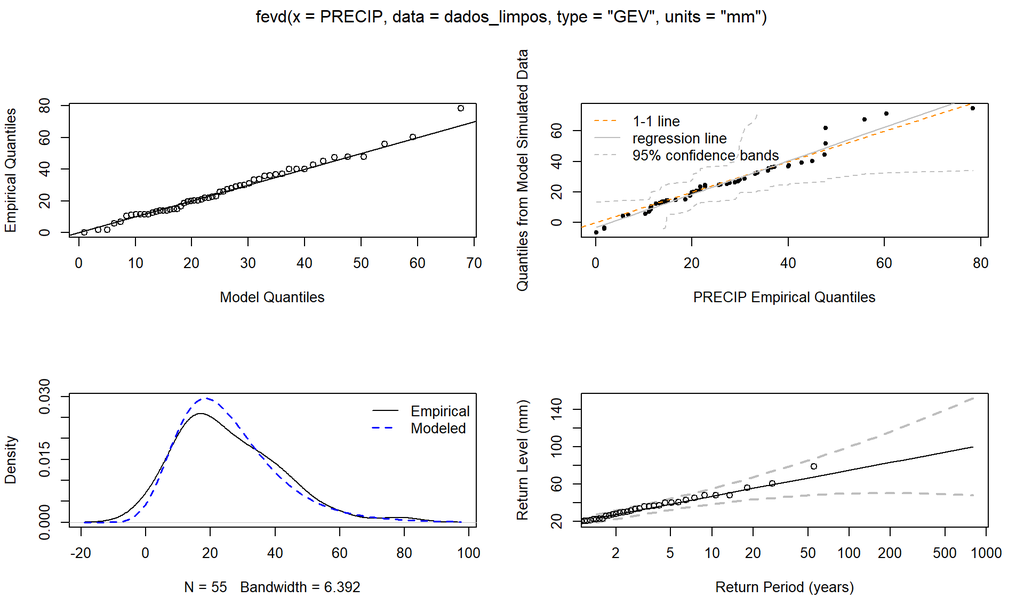

## 8.2 Maio

### 8.2.1 Precipitação - Maio

> Tamanho da amostra analisada (sem NAs): 55 anos.

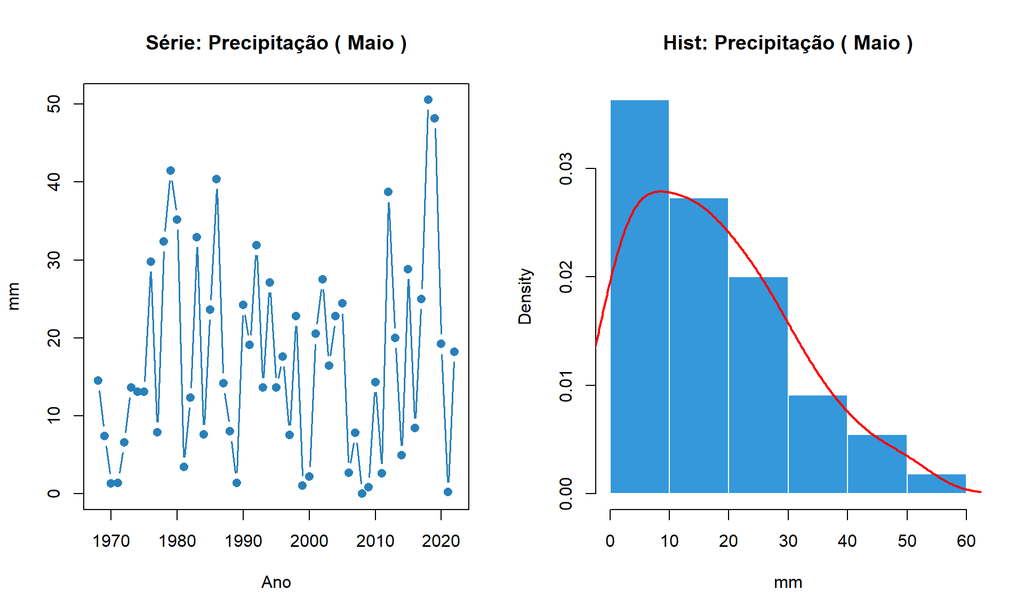

**Diagnóstico de Estacionariedade (ADF - Chuva):**

# 9 Augmented Dickey-Fuller Test Unit Root Test

Test regression trend

Call: lm(formula = z.diff ~ z.lag.1 + 1 + tt + z.diff.lag)

Residuals: Min 1Q Median 3Q Max -18.849 -11.531 -2.381 10.146 29.145

Coefficients: Estimate Std. Error t value Pr(>|t|)  
(Intercept) 13.10318 4.54898 2.880 0.00587 ** z.lag.1 -0.84743 0.17863 -4.744 1.85e-05 *** tt 0.06069 0.12004 0.506 0.61544  
z.diff.lag 0.09059 0.14514 0.624 0.53544  
— Signif. codes: 0 ‘**’ 0.001 ’**’ 0.01 ’’ 0.05 ‘.’ 0.1 ’ ’ 1

Residual standard error: 13.17 on 49 degrees of freedom Multiple R-squared: 0.395, Adjusted R-squared: 0.358 F-statistic: 10.67 on 3 and 49 DF, p-value: 1.647e-05

Value of test-statistic is: -4.7439 7.5303 11.2936

Critical values for test statistics: 1pct 5pct 10pct tau3 -4.04 -3.45 -3.15 phi2 6.50 4.88 4.16 phi3 8.73 6.49 5.47

**Seleção de Modelo GEV (TRV: Estacionário vs. ONI):**

> **Resultado do TRV:** P-valor = 0.005 **Decisão:** Rejeitamos a hipótese nula. A inclusão do ONI melhora o modelo significativamente. Mantendo o GEV NÃO-ESTACIONÁRIO.

fevd(x = PRECIP, data = dados_limpos, location.fun = ~ONI_Atual, type = “GEV”, units = “mm”)

[1] “Estimation Method used: MLE”

Negative Log-Likelihood Value: 211.3305

Estimated parameters: mu0 mu1 scale shape 11.21799425 6.39010168 9.20926587 0.06742233

Standard Error Estimates: mu0 mu1 scale shape 1.5687851 2.2807082 1.2405685 0.1702776

Estimated parameter covariance matrix. mu0 mu1 scale shape mu0 2.4610868 0.6279645 1.1311532 -0.14381153 mu1 0.6279645 5.2016298 0.5527648 -0.10751281 scale 1.1311532 0.5527648 1.5390103 -0.11080609 shape -0.1438115 -0.1075128 -0.1108061 0.02899446

AIC = 430.6609

BIC = 438.6902 $par mu0 mu1 scale shape 11.21799425 6.39010168 9.20926587 0.06742233

$cov.theta mu0 mu1 scale shape mu0 2.4610868 0.6279645 1.1311532 -0.14381153 mu1 0.6279645 5.2016298 0.5527648 -0.10751281 scale 1.1311532 0.5527648 1.5390103 -0.11080609 shape -0.1438115 -0.1075128 -0.1108061 0.02899446

$se.theta mu0 mu1 scale shape 1.5687851 2.2807082 1.2405685 0.1702776

$nllh [1] 211.3305

$AIC [1] 430.6609

$BIC [1] 438.6902

## 9.1

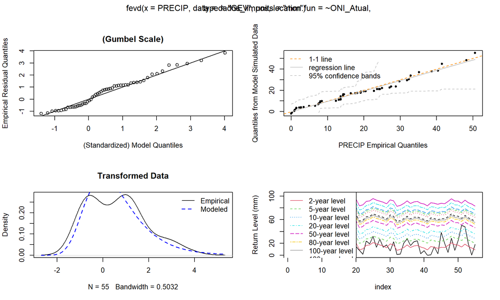

## 9.2 Junho

### 9.2.1 Precipitação - Junho

> Tamanho da amostra analisada (sem NAs): 55 anos.

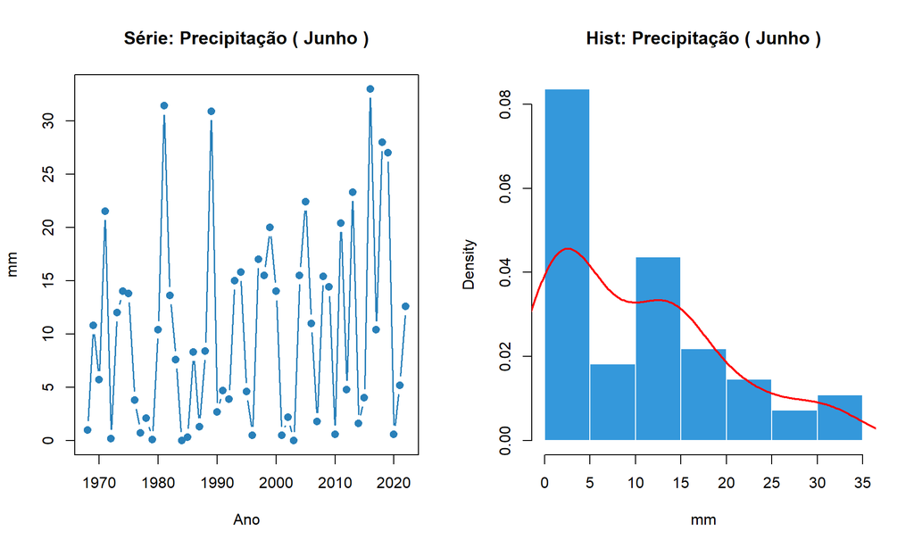

**Diagnóstico de Estacionariedade (ADF - Chuva):**

# 10 Augmented Dickey-Fuller Test Unit Root Test

Test regression trend

Call: lm(formula = z.diff ~ z.lag.1 + 1 + tt + z.diff.lag)

Residuals: Min 1Q Median 3Q Max -13.399 -7.638 -1.541 5.138 21.080

Coefficients: Estimate Std. Error t value Pr(>|t|)  
(Intercept) 8.78609 3.02496 2.905 0.0055 ** z.lag.1 -1.20510 0.20090 -5.998 2.35e-07 *** tt 0.13573 0.08711 1.558 0.1256  
z.diff.lag 0.18475 0.14076 1.312 0.1955  
— Signif. codes: 0 ‘**’ 0.001 ’**’ 0.01 ’’ 0.05 ‘.’ 0.1 ’ ’ 1

Residual standard error: 9.322 on 49 degrees of freedom Multiple R-squared: 0.5254, Adjusted R-squared: 0.4963 F-statistic: 18.08 on 3 and 49 DF, p-value: 4.916e-08

Value of test-statistic is: -5.9984 11.9972 17.9945

Critical values for test statistics: 1pct 5pct 10pct tau3 -4.04 -3.45 -3.15 phi2 6.50 4.88 4.16 phi3 8.73 6.49 5.47

**Seleção de Modelo GEV (TRV: Estacionário vs. ONI):**

> **Erro:** Houve falha na convergência de um dos modelos para este mês. Verifique os dados ou a estabilidade numérica.

## 10.1 Julho

### 10.1.1 Precipitação - Julho

> Tamanho da amostra analisada (sem NAs): 55 anos.

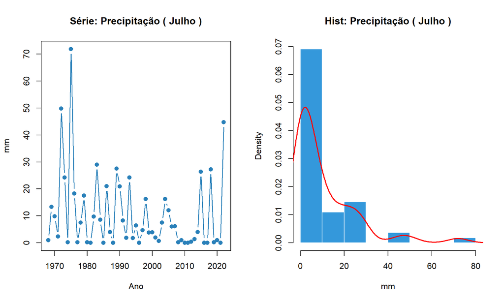

**Diagnóstico de Estacionariedade (ADF - Chuva):**

# 11 Augmented Dickey-Fuller Test Unit Root Test

Test regression trend

Call: lm(formula = z.diff ~ z.lag.1 + 1 + tt + z.diff.lag)

Residuals: Min 1Q Median 3Q Max -15.735 -9.039 -3.940 5.189 56.510

Coefficients: Estimate Std. Error t value Pr(>|t|)  
(Intercept) 24.0068 5.6701 4.234 0.000101 *z.lag.1 -1.4134 0.2244 -6.298 8.11e-08* tt -0.3413 0.1414 -2.413 0.019584 *  
z.diff.lag 0.2561 0.1495 1.712 0.093137 .  
— Signif. codes: 0 ‘**’ 0.001 ’**’ 0.01 ’’ 0.05 ‘.’ 0.1 ’ ’ 1

Residual standard error: 14.02 on 49 degrees of freedom Multiple R-squared: 0.5476, Adjusted R-squared: 0.52 F-statistic: 19.77 on 3 and 49 DF, p-value: 1.545e-08

Value of test-statistic is: -6.2981 13.3367 19.9591

Critical values for test statistics: 1pct 5pct 10pct tau3 -4.04 -3.45 -3.15 phi2 6.50 4.88 4.16 phi3 8.73 6.49 5.47

**Seleção de Modelo GEV (TRV: Estacionário vs. ONI):**

> **Resultado do TRV:** P-valor = 1 **Decisão:** Falhamos em rejeitar a hipótese nula. A influência do ONI não justificou a perda de grau de liberdade. Mantendo o GEV ESTACIONÁRIO.

fevd(x = PRECIP, data = dados_limpos, type = “GEV”, units = “mm”)

[1] “Estimation Method used: MLE”

Negative Log-Likelihood Value: 157.9294

Estimated parameters: location scale shape 0.3755457 2.1052966 5.6058373

Standard Error Estimates: location scale shape 2e-08 2e-08 2e-08

Estimated parameter covariance matrix. location scale shape location 4.000000e-16 8.599635e-26 -3.168009e-26 scale 8.599635e-26 4.000000e-16 1.287712e-25 shape -3.168009e-26 1.287712e-25 4.000000e-16

AIC = 321.8588

BIC = 327.8808 $par location scale shape 0.3755457 2.1052966 5.6058373

$cov.theta location scale shape location 4.000000e-16 8.599635e-26 -3.168009e-26 scale 8.599635e-26 4.000000e-16 1.287712e-25 shape -3.168009e-26 1.287712e-25 4.000000e-16

$se.theta location scale shape 2e-08 2e-08 2e-08

$nllh [1] 157.9294

$AIC [1] 321.8588

$BIC [1] 327.8808

## 11.1

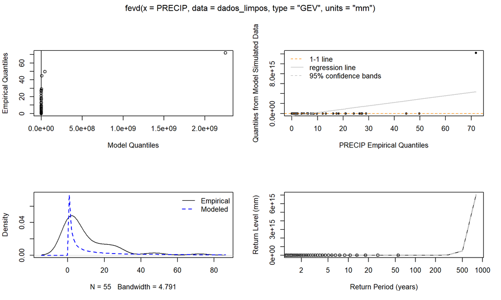

## 11.2 Agosto

### 11.2.1 Precipitação - Agosto

> Tamanho da amostra analisada (sem NAs): 55 anos.

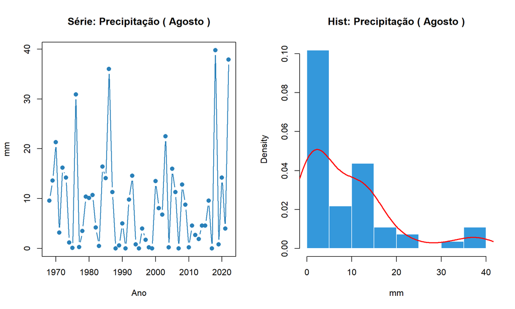

**Diagnóstico de Estacionariedade (ADF - Chuva):**

# 12 Augmented Dickey-Fuller Test Unit Root Test

Test regression trend

Call: lm(formula = z.diff ~ z.lag.1 + 1 + tt + z.diff.lag)

Residuals: Min 1Q Median 3Q Max -10.231 -7.248 -3.544 4.082 29.737

Coefficients: Estimate Std. Error t value Pr(>|t|)  
(Intercept) 9.340095 3.773538 2.475 0.0168 *  
z.lag.1 -1.072818 0.235049 -4.564 3.38e-05 *** tt 0.002015 0.092828 0.022 0.9828  
z.diff.lag -0.064825 0.156594 -0.414 0.6807  
— Signif. codes: 0 ‘**’ 0.001 ’**’ 0.01 ’’ 0.05 ‘.’ 0.1 ’ ’ 1

Residual standard error: 10.21 on 49 degrees of freedom Multiple R-squared: 0.5304, Adjusted R-squared: 0.5016 F-statistic: 18.45 on 3 and 49 DF, p-value: 3.813e-08

Value of test-statistic is: -4.5642 7.1613 10.7023

Critical values for test statistics: 1pct 5pct 10pct tau3 -4.04 -3.45 -3.15 phi2 6.50 4.88 4.16 phi3 8.73 6.49 5.47

**Seleção de Modelo GEV (TRV: Estacionário vs. ONI):**

> **Resultado do TRV:** P-valor = 0.2186 **Decisão:** Falhamos em rejeitar a hipótese nula. A influência do ONI não justificou a perda de grau de liberdade. Mantendo o GEV ESTACIONÁRIO.

fevd(x = PRECIP, data = dados_limpos, type = “GEV”, units = “mm”)

[1] “Estimation Method used: MLE”

Negative Log-Likelihood Value: 184.2522

Estimated parameters: location scale shape 2.056854 3.284947 1.166010

Standard Error Estimates: location scale shape 0.9338604 1.0394718 0.5419418

Estimated parameter covariance matrix. location scale shape location 0.8720952 0.9044127 -0.4074844 scale 0.9044127 1.0805016 -0.3258046 shape -0.4074844 -0.3258046 0.2937009

AIC = 374.5043

BIC = 380.5263 $par location scale shape 2.056854 3.284947 1.166010

$cov.theta location scale shape location 0.8720952 0.9044127 -0.4074844 scale 0.9044127 1.0805016 -0.3258046 shape -0.4074844 -0.3258046 0.2937009

$se.theta location scale shape 0.9338604 1.0394718 0.5419418

$nllh [1] 184.2522

$AIC [1] 374.5043

$BIC [1] 380.5263

## 12.1

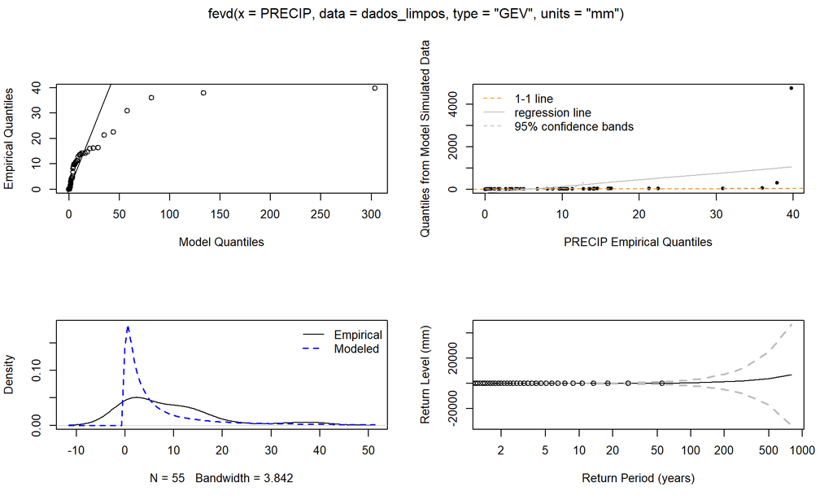

## 12.2 Setembro

### 12.2.1 Precipitação - Setembro

> Tamanho da amostra analisada (sem NAs): 55 anos.

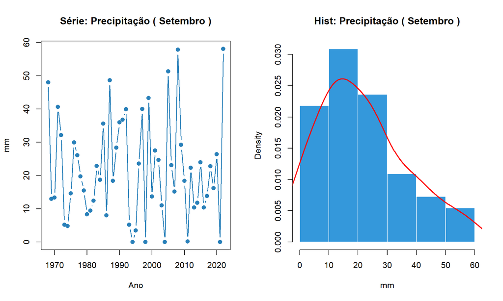

**Diagnóstico de Estacionariedade (ADF - Chuva):**

# 13 Augmented Dickey-Fuller Test Unit Root Test

Test regression trend

Call: lm(formula = z.diff ~ z.lag.1 + 1 + tt + z.diff.lag)

Residuals: Min 1Q Median 3Q Max -22.530 -11.165 -1.047 7.804 35.682

Coefficients: Estimate Std. Error t value Pr(>|t|)  
(Intercept) 23.83291 6.54252 3.643 0.00065 *z.lag.1 -1.14928 0.21909 -5.246 3.31e-06* tt 0.01976 0.13803 0.143 0.88675  
z.diff.lag 0.02998 0.14909 0.201 0.84147  
— Signif. codes: 0 ‘**’ 0.001 ’**’ 0.01 ’’ 0.05 ‘.’ 0.1 ’ ’ 1

Residual standard error: 15.33 on 49 degrees of freedom Multiple R-squared: 0.5295, Adjusted R-squared: 0.5007 F-statistic: 18.38 on 3 and 49 DF, p-value: 3.979e-08

Value of test-statistic is: -5.2458 9.2683 13.8875

Critical values for test statistics: 1pct 5pct 10pct tau3 -4.04 -3.45 -3.15 phi2 6.50 4.88 4.16 phi3 8.73 6.49 5.47

**Seleção de Modelo GEV (TRV: Estacionário vs. ONI):**

> **Resultado do TRV:** P-valor = 0.0859 **Decisão:** Falhamos em rejeitar a hipótese nula. A influência do ONI não justificou a perda de grau de liberdade. Mantendo o GEV ESTACIONÁRIO.

fevd(x = PRECIP, data = dados_limpos, type = “GEV”, units = “mm”)

[1] “Estimation Method used: MLE”

Negative Log-Likelihood Value: 224.2508

Estimated parameters: location scale shape 14.79475785 12.30783240 -0.03041513

Standard Error Estimates: location scale shape 1.9406545 1.4440210 0.1273378

Estimated parameter covariance matrix. location scale shape location 3.7661398 1.15135221 -0.10910746 scale 1.1513522 2.08519657 -0.08260435 shape -0.1091075 -0.08260435 0.01621492

AIC = 454.5016

BIC = 460.5236 $par location scale shape 14.79475785 12.30783240 -0.03041513

$cov.theta location scale shape location 3.7661398 1.15135221 -0.10910746 scale 1.1513522 2.08519657 -0.08260435 shape -0.1091075 -0.08260435 0.01621492

$se.theta location scale shape 1.9406545 1.4440210 0.1273378

$nllh [1] 224.2508

$AIC [1] 454.5016

$BIC [1] 460.5236

## 13.1

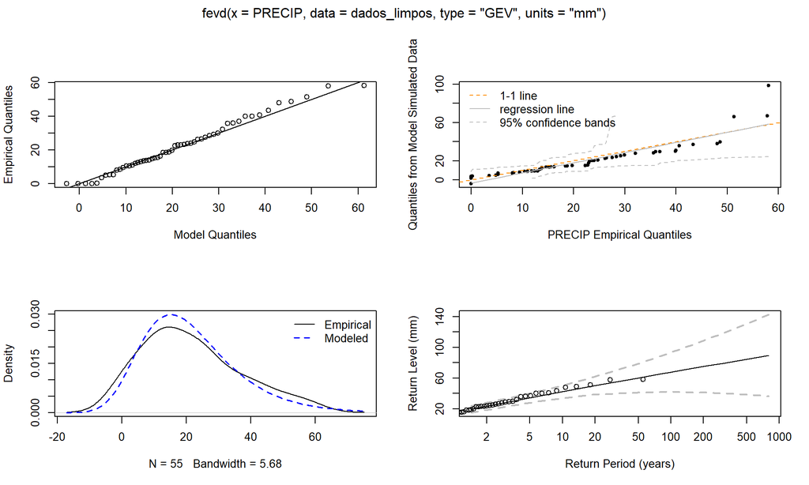

## 13.2 Outubro

### 13.2.1 Precipitação - Outubro

> Tamanho da amostra analisada (sem NAs): 55 anos.

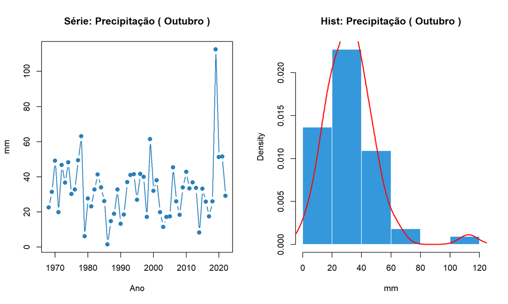

**Diagnóstico de Estacionariedade (ADF - Chuva):**

# 14 Augmented Dickey-Fuller Test Unit Root Test

Test regression trend

Call: lm(formula = z.diff ~ z.lag.1 + 1 + tt + z.diff.lag)

Residuals: Min 1Q Median 3Q Max -29.926 -11.364 -0.822 7.602 79.618

Coefficients: Estimate Std. Error t value Pr(>|t|)  
(Intercept) 25.71411 7.66811 3.353 0.00155 ** z.lag.1 -0.84245 0.18819 -4.477 4.53e-05 *** tt 0.06669 0.16194 0.412 0.68229  
z.diff.lag -0.02669 0.14412 -0.185 0.85383  
— Signif. codes: 0 ‘**’ 0.001 ’**’ 0.01 ’’ 0.05 ‘.’ 0.1 ’ ’ 1

Residual standard error: 17.95 on 49 degrees of freedom Multiple R-squared: 0.4326, Adjusted R-squared: 0.3979 F-statistic: 12.45 on 3 and 49 DF, p-value: 3.572e-06

Value of test-statistic is: -4.4766 6.6823 10.02

Critical values for test statistics: 1pct 5pct 10pct tau3 -4.04 -3.45 -3.15 phi2 6.50 4.88 4.16 phi3 8.73 6.49 5.47

**Seleção de Modelo GEV (TRV: Estacionário vs. ONI):**

> **Erro:** Houve falha na convergência de um dos modelos para este mês. Verifique os dados ou a estabilidade numérica.

## 14.1 Novembro

### 14.1.1 Precipitação - Novembro

> Tamanho da amostra analisada (sem NAs): 55 anos.

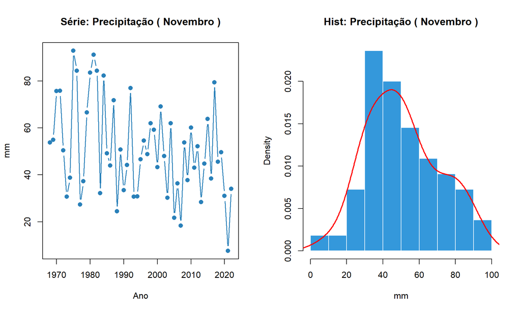

**Diagnóstico de Estacionariedade (ADF - Chuva):**

# 15 Augmented Dickey-Fuller Test Unit Root Test

Test regression trend

Call: lm(formula = z.diff ~ z.lag.1 + 1 + tt + z.diff.lag)

Residuals: Min 1Q Median 3Q Max -31.550 -14.413 -1.518 14.038 41.258

Coefficients: Estimate Std. Error t value Pr(>|t|)  
(Intercept) 69.4971 13.8613 5.014 7.38e-06 *z.lag.1 -1.0866 0.2015 -5.393 1.98e-06* tt -0.5148 0.1939 -2.656 0.0106 *  
z.diff.lag 0.1104 0.1458 0.757 0.4526  
— Signif. codes: 0 ‘**’ 0.001 ’**’ 0.01 ’’ 0.05 ‘.’ 0.1 ’ ’ 1

Residual standard error: 19.48 on 49 degrees of freedom Multiple R-squared: 0.4958, Adjusted R-squared: 0.4649 F-statistic: 16.06 on 3 and 49 DF, p-value: 2.105e-07

Value of test-statistic is: -5.393 9.7715 14.6142

Critical values for test statistics: 1pct 5pct 10pct tau3 -4.04 -3.45 -3.15 phi2 6.50 4.88 4.16 phi3 8.73 6.49 5.47

**Seleção de Modelo GEV (TRV: Estacionário vs. ONI):**

> **Resultado do TRV:** P-valor = 0.1579 **Decisão:** Falhamos em rejeitar a hipótese nula. A influência do ONI não justificou a perda de grau de liberdade. Mantendo o GEV ESTACIONÁRIO.

fevd(x = PRECIP, data = dados_limpos, type = “GEV”, units = “mm”)

[1] “Estimation Method used: MLE”

Negative Log-Likelihood Value: 241.4625

Estimated parameters: location scale shape 42.9418708 18.4396956 -0.1940002

Standard Error Estimates: location scale shape 2.8381210 2.0473277 0.1144137

Estimated parameter covariance matrix. location scale shape location 8.0549311 1.1627683 -0.14089164 scale 1.1627683 4.1915509 -0.12805345 shape -0.1408916 -0.1280534 0.01309049

AIC = 488.925

BIC = 494.947 $par location scale shape 42.9418708 18.4396956 -0.1940002

$cov.theta location scale shape location 8.0549311 1.1627683 -0.14089164 scale 1.1627683 4.1915509 -0.12805345 shape -0.1408916 -0.1280534 0.01309049

$se.theta location scale shape 2.8381210 2.0473277 0.1144137

$nllh [1] 241.4625

$AIC [1] 488.925

$BIC [1] 494.947

## 15.1

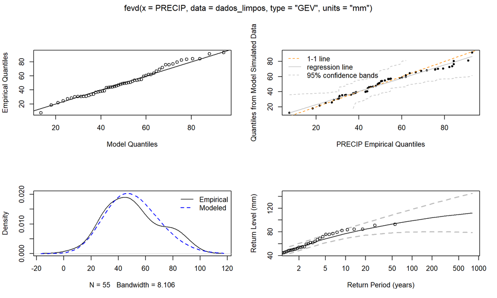

## 15.2 Dezembro

### 15.2.1 Precipitação - Dezembro

> Tamanho da amostra analisada (sem NAs): 55 anos.

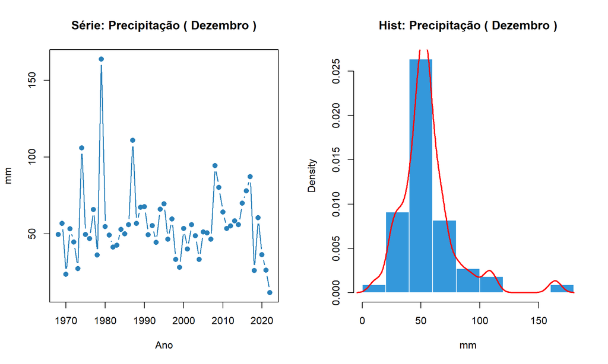

**Diagnóstico de Estacionariedade (ADF - Chuva):**

# 16 Augmented Dickey-Fuller Test Unit Root Test

Test regression trend

Call: lm(formula = z.diff ~ z.lag.1 + 1 + tt + z.diff.lag)

Residuals: Min 1Q Median 3Q Max -38.089 -12.646 -2.143 5.709 104.673

Coefficients: Estimate Std. Error t value Pr(>|t|)  
(Intercept) 54.87946 14.21739 3.860 0.000332 *z.lag.1 -0.90739 0.21367 -4.247 9.65e-05* tt -0.15854 0.22529 -0.704 0.484957  
z.diff.lag -0.09253 0.14874 -0.622 0.536732  
— Signif. codes: 0 ‘**’ 0.001 ’**’ 0.01 ’’ 0.05 ‘.’ 0.1 ’ ’ 1

Residual standard error: 25.07 on 49 degrees of freedom Multiple R-squared: 0.4927, Adjusted R-squared: 0.4616 F-statistic: 15.86 on 3 and 49 DF, p-value: 2.439e-07

Value of test-statistic is: -4.2467 6.171 9.2058

Critical values for test statistics: 1pct 5pct 10pct tau3 -4.04 -3.45 -3.15 phi2 6.50 4.88 4.16 phi3 8.73 6.49 5.47

**Seleção de Modelo GEV (TRV: Estacionário vs. ONI):**

> **Erro:** Houve falha na convergência de um dos modelos para este mês. Verifique os dados ou a estabilidade numérica.